# Algorithm Development and Speed Comparisons

This notebook documents the development of the worn indicator algorithm, comparing different implementation approaches:

- Pure pandas (slow)
- Pandas with rolling windows (slow)
- Pure numpy (moderate)
- Numba-compiled numpy (fast)

This is educational/development code - for production data processing, use `01_pipeline.ipynb` which uses the fastest approach.

# Imports

```python
import subprocess

import altair as alt
import numpy as np
import pandas as pd
from tqdm import tqdm

from utils import (
    CHAR_LOOKUP,
    get_datadir,
    worn_indicator_pandas_single,
    worn_indicator_pandas_rolling,
    worn_indicator_numpy_single,
    worn_indicator_numpy,
    worn_indicator_numba_single,
    worn_indicator_numba,
)
```

```python
pd.set_option("display.max_columns", None)
pd.set_option("display.max_rows", 1000)
alt.data_transformers.enable("vegafusion")
alt.renderers.enable('png')
tqdm.pandas()
```

# Load raw data

```python
year: str = "2003-2004"
```

```python
datadir = get_datadir(year)
parquetfile = datadir / f"paxraw_{CHAR_LOOKUP[year].lower()}.parquet"

paxraw = pd.read_parquet(parquetfile)
```

```python
paxraw.shape
```

```
(72250027, 8)
```

# Work with a sample of data

For development, use a single person's data to test algorithms quickly.

```python
paxraw_sample = paxraw.loc[paxraw.SEQN == paxraw.SEQN.values[0], :].copy()
paxraw_sample.shape
```

```
(10080, 8)
```

```python
min_worn_hours_threshold: int = 10
max_nonzero_count_per_unworn_hour: int = 2
max_of_nonzero_in_unworn_hour: int = 100
MINUTES_PER_HOUR = 60
```

# Approach 1: Pure pandas with iloc

This approach uses pandas iloc for iteration - turns out it's very slow due to pandas overhead.

```python
paxraw_sample.loc[:, "worn"] = True
PAXINTEN_col = np.arange(paxraw_sample.shape[1])[paxraw_sample.columns == "PAXINTEN"][0]
worn_col = np.arange(paxraw_sample.shape[1])[paxraw_sample.columns == "worn"][0]
```

```python
# First hour check
if (paxraw_sample.iloc[:60, PAXINTEN_col] >= 100).sum() <= 2:
    paxraw_sample.iloc[:60, worn_col] = False
```

```python
for i in range(61, paxraw_sample.shape[0]):
    if (paxraw_sample.iloc[(i - 60) : i, PAXINTEN_col] >= 100).sum() <= 2:
        paxraw_sample.iloc[(i - 60) : i, worn_col] = False
```

## Visualize worn indicator results

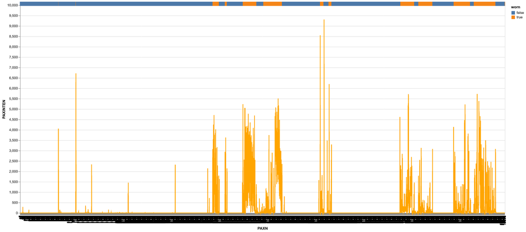

```python
worn_chart = (
    alt.Chart(paxraw_sample)
    .mark_bar(width=1)
    .encode(x="PAXN:O", y=alt.value(-10), y2=alt.value(2), color="worn")
)
inten_chart = alt.Chart(paxraw_sample).mark_line(color="orange").encode(x="PAXN:O", y="PAXINTEN")
if "PAXSTEP" in paxraw_sample.columns:
    step_chart = alt.Chart(paxraw_sample).mark_line().encode(x="PAXN:O", y="PAXSTEP")
    chart = worn_chart + inten_chart + step_chart
else:
    chart = worn_chart + inten_chart
chart.properties(width=1400, height=600)
```

## Correct the logic

The above had incorrect logic. The correct definition:

- Only 2 allowed > 0, AND all 60 are strictly less than 100

```python
# Reset and apply correct logic
paxraw_sample.loc[:, "worn"] = True

# First hour
if ((paxraw_sample.iloc[:60, PAXINTEN_col] > 0).sum() <= 2) and (
    (paxraw_sample.iloc[:60, PAXINTEN_col] < 100).sum() == 60
):
    paxraw_sample.iloc[:60, worn_col] = False
```

```python
for i in range(61, paxraw_sample.shape[0]):
    if ((paxraw_sample.iloc[(i - 60) : i, PAXINTEN_col] > 0).sum() <= 2) and (
        (paxraw_sample.iloc[(i - 60) : i, PAXINTEN_col] < 100).sum() == 60
    ):
        paxraw_sample.iloc[(i - 60) : i, worn_col] = False
```

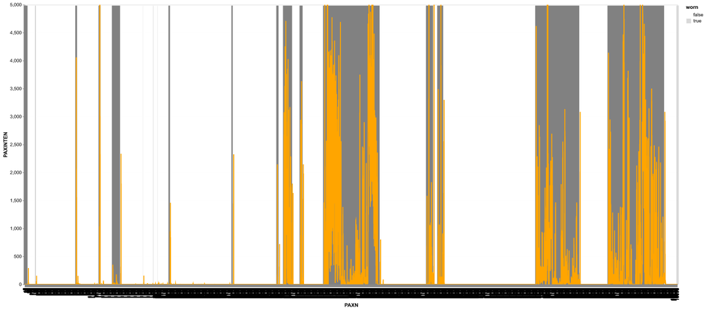

```python
(
    alt.Chart(paxraw_sample)
    .mark_bar(width=5, opacity=0.3)
    .encode(
        x="PAXN:O",
        y=alt.value(600),
        y2=alt.value(2),
        color=alt.Color("worn", scale=alt.Scale(range=["white", "grey"])),
    )
    + alt.Chart(paxraw_sample)
    .mark_line(color="orange", clip=True)
    .encode(x="PAXN:O", y=alt.Y("PAXINTEN", scale=alt.Scale(domain=[0, 5000])))
).properties(width=1400, height=600)
```

## Try inverse logic (start unworn, set to worn)

```python
# Start with worn = False
paxraw_sample.loc[:, "worn"] = False

if ((paxraw_sample.iloc[:60, PAXINTEN_col] > 0).sum() > 2) or (
    (paxraw_sample.iloc[:60, PAXINTEN_col] >= 100).sum() > 0
):
    paxraw_sample.iloc[:60, worn_col] = True

for i in range(61, paxraw_sample.shape[0]):
    if ((paxraw_sample.iloc[(i - 60) : i, PAXINTEN_col] > 0).sum() > 2) or (
        (paxraw_sample.iloc[(i - 60) : i, PAXINTEN_col] >= 100).sum() > 0
    ):
        paxraw_sample.iloc[(i - worn_col) : i, worn_col] = True
```

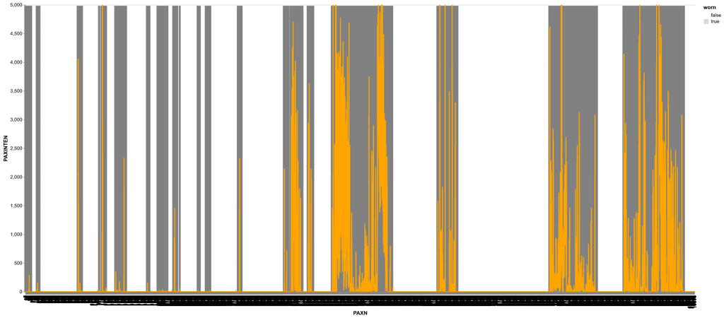

```python
(
    alt.Chart(paxraw_sample)
    .mark_bar(width=5, opacity=0.3)
    .encode(
        x="PAXN:O",
        y=alt.value(600),
        y2=alt.value(2),
        color=alt.Color("worn", scale=alt.Scale(range=["white", "grey"])),
    )
    + alt.Chart(paxraw_sample)
    .mark_line(color="orange", clip=True)
    .encode(x="PAXN:O", y=alt.Y("PAXINTEN", scale=alt.Scale(domain=[0, 5000])))
).properties(width=1400, height=600)
```

# Approach 2: Simple numpy array loop

A straightforward implementation using numpy arrays and a for loop.

```python
# Initialize worn indicator
worn = np.ones(paxraw_sample.shape[0])
paxinten = paxraw_sample.PAXINTEN.values
```

```python
# Check first hour
if ((paxinten[:MINUTES_PER_HOUR] > 0).sum() <= max_nonzero_count_per_unworn_hour) and (
    (paxinten[:MINUTES_PER_HOUR] < max_of_nonzero_in_unworn_hour).sum() == MINUTES_PER_HOUR
):
    worn[:MINUTES_PER_HOUR] = 0
```

```python
# Main loop
for i in range(MINUTES_PER_HOUR + 1, worn.shape[0]):
    if ((paxinten[(i - MINUTES_PER_HOUR) : i] > 0).sum() <= max_nonzero_count_per_unworn_hour) and (
        (paxinten[(i - MINUTES_PER_HOUR) : i] < max_of_nonzero_in_unworn_hour).sum()
        == MINUTES_PER_HOUR
    ):
        worn[(i - MINUTES_PER_HOUR) : i] = 0
```

# Approach 3: Use `numba` and apply to full dataset

This is faster on the single person data and also a tad faster when doing the "looping" over people using numba directly (passing the whole vector of values for the full df to numba, rather than per-person).

Since it's `@jit` compiled, the numba versions are in the utils.py folder here. We've also written the implementations of the other approaches in the utils script so we can compare them.

# Timing Comparisons

Compare all approaches on a single person's data.

```python
# Compile numba function first (so compilation time isn't included)
_ = worn_indicator_numba_single(paxraw_sample.PAXINTEN.values)
```

```python
# Time all single-person approaches
t_pandas_iloc = %timeit -o -q worn_indicator_pandas_single(paxraw_sample.PAXINTEN.values)
t_pandas_rolling = %timeit -o -q worn_indicator_pandas_rolling(paxraw_sample.PAXINTEN.values)
t_numpy = %timeit -o -q worn_indicator_numpy_single(paxraw_sample.PAXINTEN.values)
t_numba = %timeit -o -q worn_indicator_numba_single(paxraw_sample.PAXINTEN.values)
```

```python
# Build comparison table
n_people = paxraw["SEQN"].nunique()

def format_time(seconds):
    if seconds >= 1:
        return f"{seconds:.2f}s"
    elif seconds >= 0.001:
        return f"{seconds * 1000:.1f}ms"
    else:
        return f"{seconds * 1_000_000:.1f}μs"

timing_results = pd.DataFrame({
    "Approach": ["Pandas iloc", "Pandas rolling", "Numpy loop", "Numba"],
    "Function": [
        "worn_indicator_pandas_single",
        "worn_indicator_pandas_rolling",
        "worn_indicator_numpy_single",
        "worn_indicator_numba_single",
    ],
    "Time per person": [format_time(t.average) for t in [t_pandas_iloc, t_pandas_rolling, t_numpy, t_numba]],
    "Projected total": [format_time(t.average * n_people) for t in [t_pandas_iloc, t_pandas_rolling, t_numpy, t_numba]],
})
timing_results
```

|  | Approach | Function | Time per person | Projected total |
| --- | --- | --- | --- | --- |
| 0 | Pandas iloc | worn_indicator_pandas_single | 836.6ms | 6003.71s |
| 1 | Pandas rolling | worn_indicator_pandas_rolling | 407.4ms | 2923.82s |
| 2 | Numpy loop | worn_indicator_numpy_single | 22.1ms | 158.25s |
| 3 | Numba | worn_indicator_numba_single | 704.1μs | 5.05s |

# Why we don't use slow approaches

## DON'T: Apply numpy-based function to Pandas column

```
paxraw['worn'] = 1
for SEQN in tqdm(pd.unique(paxraw.SEQN.values)):
    paxraw.loc[paxraw.SEQN == SEQN, 'worn'] = worn_indicator_numpy_single(paxraw.loc[paxraw.SEQN == SEQN, 'PAXINTEN'].values)
```

## DON'T: Pandas iloc or rolling approaches

# Full Dataset vs Per-Person Loop

Comparing the actual overhead of applying functions per-person (with pandas filtering) vs operating on the full dataset directly.

```python
# Test on 10 people to see the pandas overhead
n_test = 10
paxraw_subset = paxraw.loc[paxraw.SEQN.isin(paxraw.SEQN.unique()[:n_test]), :].copy()
```

```python
# First, show that different looping strategies have similar overhead
def apply_loop_loc_twice(df, func):
    """Loop with .loc called twice per iteration (original approach)."""
    df = df.copy()
    df['worn'] = 1.0
    for SEQN in df.SEQN.unique():
        df.loc[df.SEQN == SEQN, 'worn'] = func(df.loc[df.SEQN == SEQN, 'PAXINTEN'].values)
    return df

def apply_loop_mask(df, func):
    """Loop with pre-computed mask."""
    df = df.copy()
    df['worn'] = 1.0
    for SEQN in df.SEQN.unique():
        mask = df.SEQN == SEQN
        df.loc[mask, 'worn'] = func(df.loc[mask, 'PAXINTEN'].values)
    return df

def apply_groupby(df, func):
    """Groupby transform."""
    df = df.copy()
    df['worn'] = df.groupby('SEQN')['PAXINTEN'].transform(lambda x: func(x.values))
    return df

# Compare looping strategies using numba_single as the function
t_loc_twice = %timeit -o -q -n1 -r3 apply_loop_loc_twice(paxraw_subset, worn_indicator_numba_single)
t_mask = %timeit -o -q -n1 -r3 apply_loop_mask(paxraw_subset, worn_indicator_numba_single)
t_groupby = %timeit -o -q -n1 -r3 apply_groupby(paxraw_subset, worn_indicator_numba_single)

looping_strategies = pd.DataFrame({
    "Looping Strategy": ["Loop .loc twice", "Loop with mask", "Groupby transform"],
    f"Time ({n_test} people)": [format_time(t.average) for t in [t_loc_twice, t_mask, t_groupby]],
})
print("All looping strategies have similar overhead (using numba_single):")
looping_strategies
```

[output not shown]

|  | Looping Strategy | Time (10 people) |
| --- | --- | --- |
| 0 | Loop .loc twice | 18.1ms |
| 1 | Loop with mask | 11.8ms |
| 2 | Groupby transform | 9.8ms |

```python
# Compare looping strategies using numba_single as the function
t_loc_twice = %timeit -o -q -n1 -r3 apply_loop_loc_twice(paxraw_subset, worn_indicator_pandas_rolling)
t_mask = %timeit -o -q -n1 -r3 apply_loop_mask(paxraw_subset, worn_indicator_pandas_rolling)
t_groupby = %timeit -o -q -n1 -r3 apply_groupby(paxraw_subset, worn_indicator_pandas_rolling)

looping_strategies = pd.DataFrame({
    "Looping Strategy": ["Loop .loc twice", "Loop with mask", "Groupby transform"],
    f"Time ({n_test} people)": [format_time(t.average) for t in [t_loc_twice, t_mask, t_groupby]],
})
print("All looping strategies have similar overhead (using pandas_rolling):")
looping_strategies
```

```
All looping strategies have similar overhead (using pandas_rolling):
```

|  | Looping Strategy | Time (10 people) |
| --- | --- | --- |
| 0 | Loop .loc twice | 4.12s |
| 1 | Loop with mask | 4.11s |
| 2 | Groupby transform | 4.09s |

```python
# Compare looping strategies using numba_single as the function
t_loc_twice = %timeit -o -q -n1 -r3 apply_loop_loc_twice(paxraw_subset, worn_indicator_numpy_single)
t_mask = %timeit -o -q -n1 -r3 apply_loop_mask(paxraw_subset, worn_indicator_numpy_single)
t_groupby = %timeit -o -q -n1 -r3 apply_groupby(paxraw_subset, worn_indicator_numpy_single)

looping_strategies = pd.DataFrame({
    "Looping Strategy": ["Loop .loc twice", "Loop with mask", "Groupby transform"],
    f"Time ({n_test} people)": [format_time(t.average) for t in [t_loc_twice, t_mask, t_groupby]],
})
print("All looping strategies have similar overhead (using numpy_single):")
looping_strategies
```

```
All looping strategies have similar overhead (using numpy_single):
```

|  | Looping Strategy | Time (10 people) |
| --- | --- | --- |
| 0 | Loop .loc twice | 205.4ms |
| 1 | Loop with mask | 200.9ms |
| 2 | Groupby transform | 199.5ms |

```python
def apply_via_loop(df, func):
    """Apply a single-person function via loop with mask."""
    df = df.copy()
    df['worn'] = 1.0
    for SEQN in df.SEQN.unique():
        mask = df.SEQN == SEQN
        df.loc[mask, 'worn'] = func(df.loc[mask, 'PAXINTEN'].values)
    return df

def apply_full_dataset(df):
    """Apply worn_indicator_numba to full dataset - fastest."""
    df = df.copy()
    df['worn'] = worn_indicator_numba(df.PAXINTEN.values, df.SEQN.values)
    return df

# Time all single-person functions applied via loop
t_pandas_iloc_loop = %timeit -o -q -n1 -r1 apply_via_loop(paxraw_subset, worn_indicator_pandas_single)
t_pandas_rolling_loop = %timeit -o -q -n1 -r1 apply_via_loop(paxraw_subset, worn_indicator_pandas_rolling)
t_numpy_loop = %timeit -o -q -n1 -r1 apply_via_loop(paxraw_subset, worn_indicator_numpy_single)
t_numba_loop = %timeit -o -q -n1 -r3 apply_via_loop(paxraw_subset, worn_indicator_numba_single)

# Time full-dataset approach on subset
t_full_subset = %timeit -o -q -n1 -r3 apply_full_dataset(paxraw_subset)
```

```python
# Compare all approaches applied via loop vs full dataset
loop_comparison = pd.DataFrame({
    "Approach": [
        "Pandas iloc (via loop)",
        "Pandas rolling (via loop)",
        "Numpy (via loop)",
        "Numba (via loop)",
        "Numba (full dataset)",
    ],
    "Function": [
        "worn_indicator_pandas_single",
        "worn_indicator_pandas_rolling",
        "worn_indicator_numpy_single",
        "worn_indicator_numba_single",
        "worn_indicator_numba",
    ],
    f"Time ({n_test} people)": [
        format_time(t_pandas_iloc_loop.average),
        format_time(t_pandas_rolling_loop.average),
        format_time(t_numpy_loop.average),
        format_time(t_numba_loop.average),
        format_time(t_full_subset.average),
    ],
    "Projected total": [
        format_time(t_pandas_iloc_loop.average / n_test * n_people),
        format_time(t_pandas_rolling_loop.average / n_test * n_people),
        format_time(t_numpy_loop.average / n_test * n_people),
        format_time(t_numba_loop.average / n_test * n_people),
        format_time(t_full_subset.average / n_test * n_people),
    ],
})
loop_comparison
```

|  | Approach | Function | Time (10 people) | Projected total |
| --- | --- | --- | --- | --- |
| 0 | Pandas iloc (via loop) | worn_indicator_pandas_single | 7.11s | 5104.27s |
| 1 | Pandas rolling (via loop) | worn_indicator_pandas_rolling | 4.08s | 2927.13s |
| 2 | Numpy (via loop) | worn_indicator_numpy_single | 204.3ms | 146.59s |
| 3 | Numba (via loop) | worn_indicator_numba_single | 11.8ms | 8.45s |
| 4 | Numba (full dataset) | worn_indicator_numba | 7.8ms | 5.59s |

```python
# Time full-dataset approaches (these are slower, so fewer runs)
t_numpy_full = %timeit -o -q -n1 -r1 worn_indicator_numpy(paxraw.PAXINTEN.values, paxraw.SEQN.values)
t_numba_full = %timeit -o -q -n1 -r3 worn_indicator_numba(paxraw.PAXINTEN.values, paxraw.SEQN.values)

print(f"Numpy full dataset ({n_people:,} people, {len(paxraw):,} rows): {format_time(t_numpy_full.average)}")
print(f"Numba full dataset ({n_people:,} people, {len(paxraw):,} rows): {format_time(t_numba_full.average)}")
```

```
Numpy full dataset (7,176 people, 72,250,027 rows): 156.67s
Numba full dataset (7,176 people, 72,250,027 rows): 5.28s
```

# Summary

Key insights:

1. Avoid pandas iloc/loc in loops - the overhead is massive
2. Numba compilation gives ~30x speedup over numpy loops
3. Operating on the full array (with SEQN checks) avoids per-person overhead

**Conclusion:** Use `worn_indicator_numba` for production.

```python
# Final comparison - using loop timings for accurate totals
final_results = pd.DataFrame({
    "Approach": [
        "Pandas iloc (via loop)",
        "Pandas rolling (via loop)",
        "Numpy (via loop)",
        "Numba (via loop)",
        "Numpy (full dataset)",
        "Numba (full dataset)",
    ],
    "Function": [
        "worn_indicator_pandas_single",
        "worn_indicator_pandas_rolling",
        "worn_indicator_numpy_single",
        "worn_indicator_numba_single",
        "worn_indicator_numpy",
        "worn_indicator_numba",
    ],
    "Time per person": [
        format_time(t_pandas_iloc.average),
        format_time(t_pandas_rolling.average),
        format_time(t_numpy.average),
        format_time(t_numba.average),
        format_time(t_numpy_full.average / n_people),
        format_time(t_numba_full.average / n_people),
    ],
    "Total time (with overhead)": [
        format_time(t_pandas_iloc_loop.average / n_test * n_people),
        format_time(t_pandas_rolling_loop.average / n_test * n_people),
        format_time(t_numpy_loop.average / n_test * n_people),
        format_time(t_numba_loop.average / n_test * n_people),
        format_time(t_numpy_full.average),
        format_time(t_numba_full.average),
    ],
})
final_results
```

|  | Approach | Function | Time per person | Total time (with overhead) |
| --- | --- | --- | --- | --- |
| 0 | Pandas iloc (via loop) | worn_indicator_pandas_single | 836.6ms | 5104.27s |
| 1 | Pandas rolling (via loop) | worn_indicator_pandas_rolling | 407.4ms | 2927.13s |
| 2 | Numpy (via loop) | worn_indicator_numpy_single | 22.1ms | 146.59s |
| 3 | Numba (via loop) | worn_indicator_numba_single | 704.1μs | 8.45s |
| 4 | Numpy (full dataset) | worn_indicator_numpy | 21.8ms | 156.67s |
| 5 | Numba (full dataset) | worn_indicator_numba | 735.1μs | 5.28s |